# assignment 4_task 2: Snowshoe Hare: Exploratory Report

Craig Stuart

11/13/2020

## 1. Introduction

- This report provides an exploratory overview of differences in weight and hind foot length of male and female juvenile snowshoe hares observed in the Bonanza Creek Experimental Forest, Long Term Ecological Research (LTER) study from 1999 - 2012 (Kielland et. al. (2017). First, the total trap counts of all juvenile snowshoe hares throughout the study are summarized. Next, the weights of male and female snowshoe hares are compared across the three grids (sites) to determine if snowshoe hare weights differ between sex and grid. Finally, it also explores if a relationship exists between juvenile snowshoe hare weight and hind foot length to determine if there is a correlation between the two physical features. Major findings are posted in the results section at the end of the report.

## 2. Data and Analyses

- Physical data on snowshoe hare were provided by a study conducted by Kielland et. al. (2017) and the Bonanza Creek Long Term Ecological Research group. The study collected capture-recapture data on snowshoe hare’s at three(3) grid, or sites, (bonrip, bonbs, bonmat) within the Bonanza Creek Experimental Forest between 1999 and 2012. The data contains 3197 observations over 14 variables, including grid, sex, age, and measurements of weight (grams) and hind foot length (millimeters). We explore the visualizations of juvenile hare trap counts and the comparisons of juvenile hare weights between sex and grid. Following exploratory data visualizations, male and female weight comparisons are analyzed statistically with a two sample t-test using a significance level ($\alpha$) of 0.05. Cohen’s d is then used to describe the differences between snowshoe hare sex. Finally, the relationship between juvenile weight and high foot length is explored by a simple linear regression. All analyses are conducted using R version 4.0.2 and RStudio Version 1.3.1073.

## 3. Exploratory Findings

### 3.1: Annual juvenile Snowshoe hare trap counts (Figure 1)

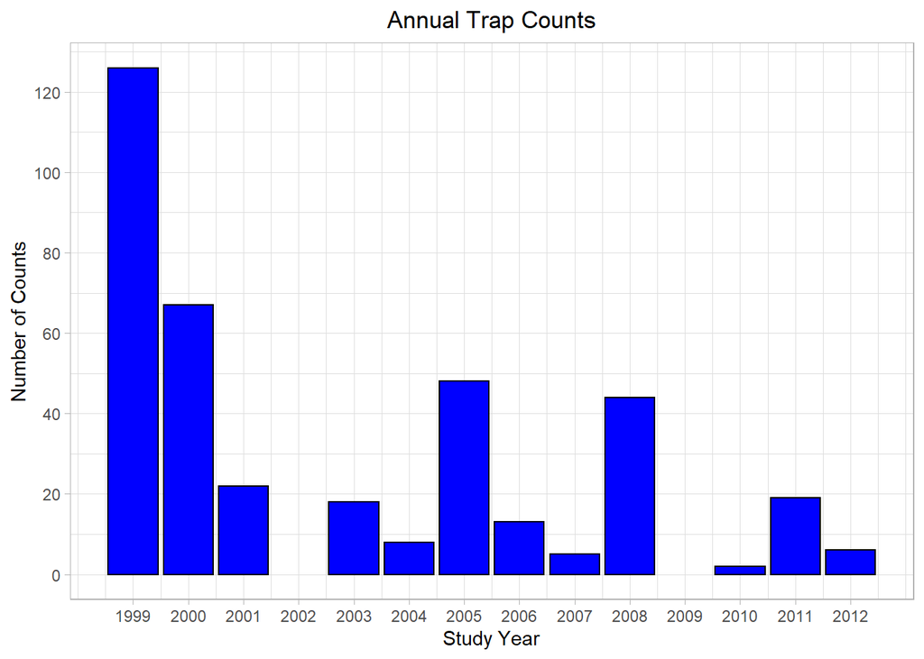

**Figure 1**: Absolute trap counts of juvenile snowshoe hare at all grids for each year of the Bonanza Creek Long Term Ecological Research (LTER) Experimental Forest study (1999-2012). Data: Kielland et. al. (2017).

- The maximum number of juvenile hare trappings occurred in 1999 (n = 126) and the minimum juvenile hare trappings occurred in 2010 (n = 2). The mean hare trappings throughout the entire study was 31.5 and the median was 18.5. Some general trends to note would be that the number of juvenile hare trappings had high variance from year to year. Also, that it’s hard to tell for if there were zero hare trappings in 2002 and 2009 or if there were no study conducted. What this graph fails to present is the amount of effort put into each year. For instance, it would make sense if in 2010 only two days resulted in 2 trap counts, but the data would be very different if only 2 trap counts were observed in 365 days of the study. Therefore, going forward, a better way to standardize the juvenile hare population is to calculate the trap count per unit effort.

### 3.2: Visualize juvenile Snowshoe hare weights

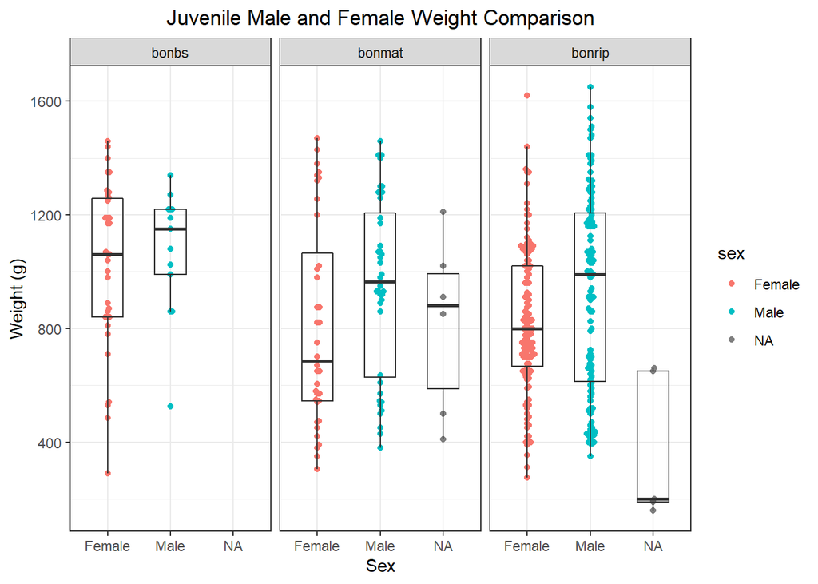

**Figure 2**: Male and female snowshoe hare weight (g) observations for three grids (bonds, bonmat, bonrip) in the Bonanza Creek LTER Experimental Forest study. Male (teal) and female (red) indicate individual observations for weight (g) of juvenile snowshoe hares. Box endpoints indicate the 25th and 75th percentile values. Data: Kielland et. al. (2017).

- The beeswarm plot helps to visualize the differences of the weight distributions among juvenile snowshoe hare sex for each grid. From this plot, it is difficult to determine if the data is normally distributed and therefore we would want to conduct further tests (histogram, quantile-quantile plot, or `pnorm()`) to determine normalcy of the data. We can generally make out that male juvenile hare weights tend to be greater than females at all three grids.

### 3.3: Juvenile weight comparison

**Table 1.** Descriptive statistics (mean, standard deviation, and sample size) for juvenile male and female snowshoe hare weights.

| Sex | Mean Hare Weight (g) | Standard deviation (g) | Sample size |
| --- | --- | --- | --- |
| f | 855.3909 | 292.2526 | 197 |
| m | 945.8589 | 333.2151 | 163 |
| NA | 614.5455 | 357.5853 | 11 |

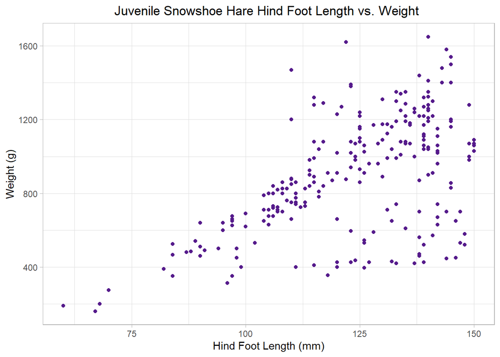

**Figure 3**: General relationship between juvenile snowshoe hare hind foot length (mm) and weight (g) from Bonanza Creek LTER Experimental Forest study. Data: Kielland et. al. (2017).

- Figure 3 shows the general relationship between hind food length and weight of juvenile snowshoe hares. The relationship appears to be slightly linear but multiple outliers appear as hind foot length increases. A simple linear regression reveals a somewhat linear relationship (p < 0.001, R<sup>2</sup> = 0.30) with an average slope of $\beta$ = 9.52 g mm<sup>-1</sup> (i.e., for each one millimeter increase in hind foot length we expect an average increase in hare weight of 9.52 g). The relationship between hind foot length and weight of juvenile Snowshoe hare is moderately, and significantly, positively correlated (Pearson’s *r* = 0.55, p < 0.001). However, diagnostic plots (not included in report) reveal that the assumption of homoscedasticity is violated because the data have a heteroscedastic spread of residuals about the model. Even though the linear regression statistics point to a significant and positive linear relationship, the assumptions tell us otherwise, Therefore, I chose not to include the plot containing the linear regression because I did not feel as this was the most responsible way to describe the relationship.

## 4. Summary

Exploratory data analysis reveals the following:

- Male snowshoe hare mean weight is greater than female snowshoe hare mean weight at all three grids in the study.
- Only 30% of variance in snowshoe hare weight is described by hind foot length.
- Although a slight linear relationship with a slope (expected average increase in weight with a 1 mm incense in hind foot length) of 9.52 g mm<sup>-1</sup> is found, the violation of the homoscedasticity assumption prevents us from using hind foot length as a variable to explain a change in weight.

Next steps:

- Calculate trap per unit effort for annual hare trap counts.
- Compare hind foot length and weight relationship between sex and grids.

## 5. Citations

- Kielland, K., F.S. Chapin, R.W. Ruess, and Bonanza Creek LTER. 2017. Snowshoe hare physical data in Bonanza Creek Experimental Forest: 1999-Present ver 22. Environmental Data Initiative. https://doi.org/10.6073/pasta/03dce4856d79b91557d8e6ce2cbcdc14